# Project: IMDB movie data analysis

> **2.3) Look at the correlation between director and revenue**

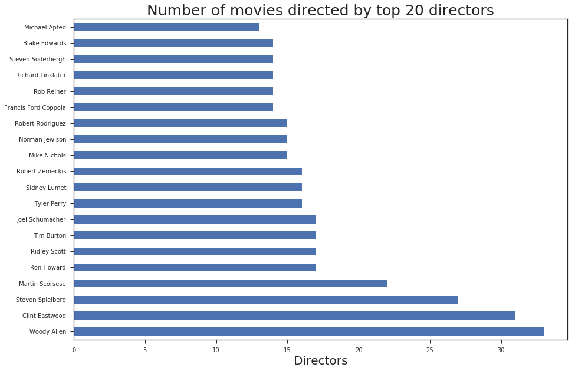

```python
# Top 20 directors
top_directors=df_director.groupby('director_split')['total_revenue'].count().sort_values(ascending=False)[:20]
top_directors.plot(kind='barh', figsize=(15,10)).yaxis.label.set_visible(False);
plt.xlabel('Directors', size=20)
plt.title('Number of movies directed by top 20 directors', size=25)
```

Now we look at the average revenue of movies per directors

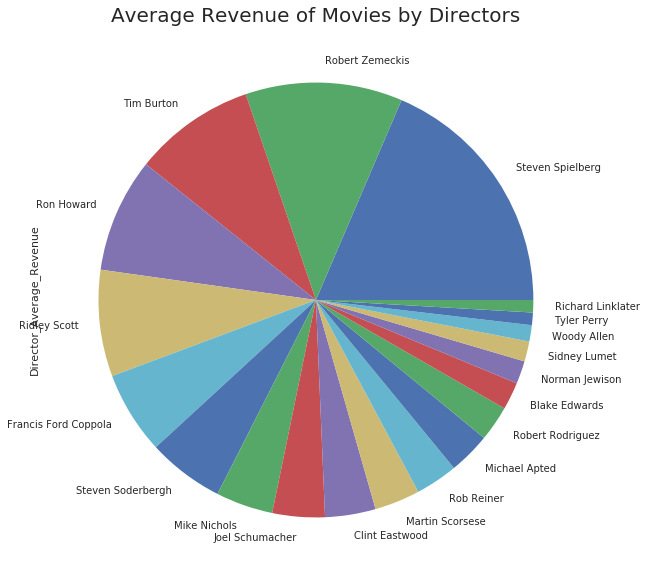

```python
# First we create an empty dict that will store director name and the average revevue
# of each directors
director_dict = {}
for actor,i in top_directors.items():
    key = actor
    value = df_director[df_director['director_split'].str.contains(actor)]['total_revenue'].mean()
    director_dict[key]=value

directors_revenue=pd.Series(director_dict, name='Director_Average_Revenue')
directors_revenue.sort_values(ascending=False).plot(kind='pie', figsize=(10,10))
plt.title('Average Revenue of Movies by Directors', size=20)
```

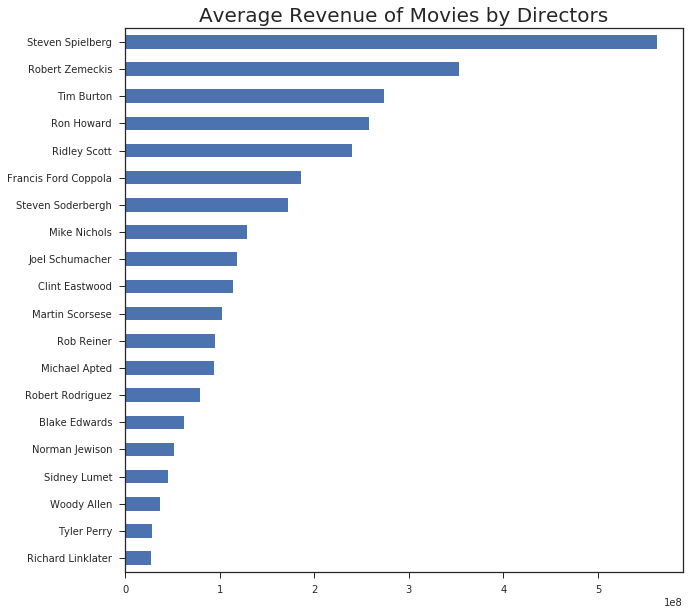

```python
directors_revenue.sort_values(ascending=True).plot(kind='barh', figsize=(10,10))
plt.title('Average Revenue of Movies by Directors', size=20)
```

As we see form the graph above, Steven Spielberg, Robert Zemeckis and Tim Button are top 3 that generate the highest revenue that they directed

> **2.4 Look at the correlation between genre and revenue**

```python
# Find the min revenue in top hundred
# and then split data into 2: below hundred and top hundred
top_hundred=df.sort_values(by=['total_revenue'], ascending=False).head(100)
min_top_hundred=top_hundred['total_revenue'].min()
min_top_hundred
```

```
721468940
```

```python
below_hundred = df_genre.query('total_revenue < 721468940')
top_hundred = df_genre.query('total_revenue >= 721468940')
print(below_hundred['genre_split'].value_counts().nlargest(5))
print(top_hundred['genre_split'].value_counts().nlargest(5))
```

```
Drama       3588
Comedy      3031
Thriller    2079
Action      1686
Romance     1312
Name: genre_split, dtype: int64
Adventure          72
Action             51
Fantasy            35
Family             31
Science Fiction    29
Name: genre_split, dtype: int64
```

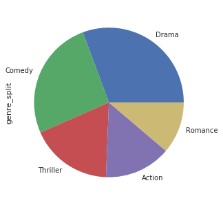

```python
below_hundred['genre_split'].value_counts().nlargest(5).plot(kind='pie',
figsize=(5,5));
```

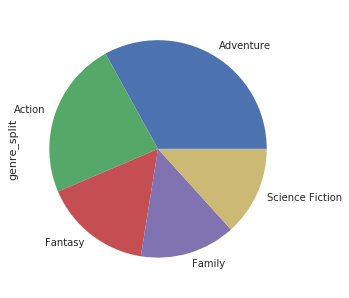

```python
top_hundred['genre_split'].value_counts().nlargest(5).plot(kind='pie', figsize=(5,5));
```

Movies that generate high revenue are Adventure, Action, Fantasy, Family and Science Ficton while Drama, Romance, Comedy and Thriller generate less revenue

## Conclusions

**References:**

1. https://pandas.pydata.org/pandas-docs/stable/user_guide/index.html
2. https://matplotlib.org/3.1.1/contents.html
3. https://seaborn.pydata.org/